None

# Table of Contents

Modified from [holomorphic functions](https://primer-computational-mathematics.github.io/book/c_mathematics/complex_analysis/4_holomorphic_functions.html)

## Holomorphic Functions

### Complex Differentiation

Let's start with the definition of a holomorphic function (also called complex analytic function)

A function $f : D \to \mathbb{C}$, where $D \subseteq \mathbb{C}$ is an open set, is *complex-differentiable at a point* $z_0 \in D$ if there exists

$$ f'(z_0) = \lim_{z \to z_0} \frac{f(z) - f(z_0)}{z - z_0} \in \mathbb{C}. $$

If $f : D \to \mathbb{C}$ is differentiable at all points of $D$, we say it is **holomorphic** (often **analytic**) in $D$. If a function is holomorphic in $\mathbb{C}$ we say that it is **entire**.

**Examples:**

- $z$ is entire
- all polynomials are entire
- $ 1/z $ is holomorphic in $ \mathbb{C} \backslash \{ 0 \} $
- all rational functions are holomorphic in $\mathbb{C}$ except in the zeros of their denominators
- $ \sin z, \cos z $ are entire
- $ \sqrt{z} $ is holomorphic in $\mathbb{C} \backslash (- \infty, 0]$

The following figure shows the absolute values of the quadratic $z^2$ function and its derivative.

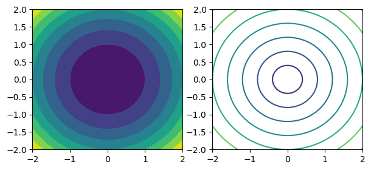

```python
import numpy as np
import matplotlib.pyplot as plt
fig = plt.figure(figsize=(7,3))
x = np.linspace(-2, 2, 50)
y = np.linspace(-2, 2, 50)
X, Y = np.meshgrid(x, y); Z = X + 1j*Y

ax1 = fig.add_subplot(121); ax2 = fig.add_subplot(122)
ax1.contourf (X,Y,np.abs(Z*Z))
ax2.contour (X,Y,np.abs(2*Z))
plt.show()
```

**Task 1**: Show real parts of the quadratic $z^2$ function and its derivative.

**Task 2**: Show imaginary parts of the quadratic $z^2$ function and its derivative.

If we go back to thinking about a derivative of a real function of one variable, recall that for the derivative to exist at $x_0$ the limit when approaching $x_0$ from the left and from the right must be equal to each other. That is because $x_0$ is just a number on the real axis. Complex numbers, however, lie on the plane, so we can approach some complex number $z_0$ from any direction. Therefore, the limit above must exist for **any angle of approach** to $z_0$ and it must always be the same. This is a very strict condition!

For $f$ to be differentiable at $z_0$ it must be **continuous** at $z_0$. That means that

$$ \lim_{z \to z_0} f(z) = f(z_0) $$

for finite $z_0, f(z_0)$. If $f$ is holomorphic on $D$ then it is continuous on $D$. Another characteristic of holomorphic functions is that they are conformal: they preserve angles between curves.

#### Differentiation rules

The addition, product, quotient and chain rules apply in complex differentiation similarly to real calculus. Let $f, g : D \to \mathbb{C}$ be differentiable at $z_0 \in D$, then:

- $\alpha f + \beta g$ is differentiable for all $ \alpha, \beta \in \mathbb{C} $ at $z_0$: $ (\alpha f + \beta g)'(z_0) = \alpha f' (z_0) + \beta g'(z_0) $
- $fg$ is differentiable at $z_0$: $(fg)'(z_0) = f'(z_0)g(z_0) + f(z_0)g'(z_o)$
- $\frac{f}{g}$ is differentiable at $z_0$ for $g(z_0) \neq 0$: $ \left( \frac{f}{g} \right)' (z_0) = \frac{f'(z_0)g(z_0) - f(z_0)g'(z_0)}{(g(z_0))^2} $
- Let $h: D_1 \to \mathbb{C}$, where $D_1$ is an open set containing $f(D)$. If $h$ is differentiable at $f(z_0)$, then $h \circ f$ is differentiable at $z_0$: $ (h \circ f)'(z_0) = h'(f(z_0))f'(z_0). $

#### Examples

Powers (n$ \geq 1$), defined on entire $\mathbb{C}$: $$ \begin{aligned} (z^n)' = nz^{n-1} \end{aligned}$$ See the color wheel plots below!

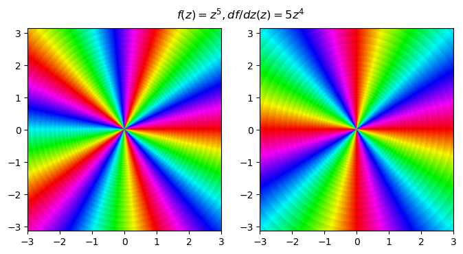

```python
from matplotlib.colors import hsv_to_rgb
fig, ax = plt.subplots(figsize=(8, 4))
x = np.linspace(-3, 3, 1000)
X, Y = np.meshgrid(x, x); Z = X + 1j*Y

def phaseplot(ax, F):
    s = 0.9                                                 # saturation
    A = np.log(np.abs(F)) * 10 / np.pi; A = A - A//1
    amin = np.min(A); amax = np.max(A)
    H = (np.angle(-F) + np.pi) / (2*np.pi)                  # hue
    V = (A-amin) / (amax-amin) * (1-s) + s                  # brightness
    img = hsv_to_rgb(np.dstack((H, np.ones(F.shape), V)))
    ax.imshow(img, extent=[min(x), max(x), min(y), max(y)])

ax1 = fig.add_subplot(121); ax2 = fig.add_subplot(122)
phaseplot (ax1, Z**5)
phaseplot (ax2, 5*Z**4)

ax.set_title('$f(z) = z^5, df/dz(z)= 5z^4$')
ax.axis('off')
plt.show()
```

All rational functions are holomorphic in $ \mathbb{C} $ except in the zeros of their denominators.

**Task 3**: Show the colorwheel plot of the function $f(z)=1/((z-1)(z+1))$. Interpret the function properties in terms of the produced plot.

**Task 4**: Show the colorwheel plot of the function $f(z)=1/((z-1)^2(z+1))$. Interpret the function properties in terms of the produced plot.

The following colorwheel plot visualizes the function $f(z)=((z-1)^2/(z+1))$. Interpret the function properties in terms of the produced plot!

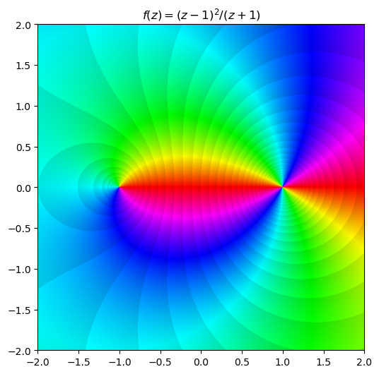

```python
fig, ax = plt.subplots(figsize=(6, 6))
x = np.linspace(-2, 2, 1000); y = x
X, Y = np.meshgrid(x, y); Z = X + 1j*Y

phaseplot (ax, (Z-1)*(Z-1)/(Z+1))
ax.set_title('$f(z) = (z-1)^2/(z+1)$')
plt.show()
```

The complex exponential is defined on entire $\mathbb{C}$ and is it's own derivative:

$$ \begin{aligned} \exp' z & = (e^x(\cos y + i \sin y))' \\ & = \partial_x u(z) + i \partial_x v(z) = \partial_x (e^x \cos y) + i \partial_x (e^x \sin y) = e^x \cos y + i e^x \sin y \\ & = \exp z \end{aligned}$$

[figure not shown]

```python
fig = plt.figure(figsize=(10,5))
x = np.linspace(-3, 3, 500)
X, Y = np.meshgrid(x, x); Z = X + 1j*Y
F = np.exp(1/Z)

ax1 = fig.add_subplot(121); ax2 = fig.add_subplot(122)
ax1.contourf (X, Y, F.real,20,cmap='prism')
ax2.contourf (X, Y, F.imag,20,cmap='prism')
ax1.set_title('$f(z) = real(exp(z))$')
ax2.set_title('$f(z) = imag(exp(z))$')
plt.show()
```

**Task 6**: Draw contourlines for the function $f(z)=exp(1/z))$ near the pole. Use the 'flag' colormap.

1/$z$ is defined on $\mathbb{C}$-{0}: $$ \begin{aligned} (1/z)' & = -1/z^2 \end{aligned}$$

Trigonometric functions are defined on entire $\mathbb{C}$:

$$ \begin{aligned} sin'(z)=cos(z), cos'(z)=-sin(z), sinh'(z)=cosh(z), cosh'(z)=sinh(z) \end{aligned}$$

The following contour plots show the absolut values of sin and cos functions in the square bounded by $\pi$ and $-\pi$.

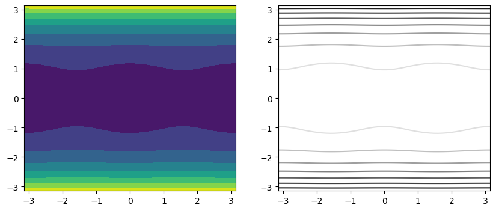

```python
fig = plt.figure(figsize=(10, 4))
x = np.linspace(-np.pi, np.pi, 50)
y = np.linspace(-np.pi, np.pi, 50)
X, Y = np.meshgrid(x, y); Z = X + 1j*Y

ax1 = fig.add_subplot(121); ax2 = fig.add_subplot(122)
ax1.contourf (X,Y,np.abs(np.sin(Z)))
ax2.contour (X,Y,np.abs(np.cos(Z)),cmap = 'binary')
plt.show()
```

### Cauchy-Riemann Conditions

**Cauchy-Riemann theorem**. A complex function $f = u + iv : D \to \mathbb{C}$ is differentiable at a point $z_0 = (x_0, y_0)$ iff the real-valued functions of two real variables $u$ and $v$ are differentiable at a point $(x_0, y_0)$ and they satisfy the **Cauchy-Riemann conditions**:

$$ \partial_x u = \partial_y v, \qquad \partial_y u = - \partial_x v. $$

named after the mathematicians Augustin-Louis Cauchy (1789-1857) and Bernhard Riemann (1826-1866), who both did groundbreaking work in complex analysis.

*Proof*: According to the definition $ f'(z_0) = \lim_{z \to z_0} \frac{f(z) - f(z_0)}{z - z_0} $ from all directions. Recall: $z=x+iy$.

Lets move towards $z_0$ from $x$-direction. Then: $f′(z)=∂f/∂x=\partial_x u+i\partial_x v$  
Similarly, taking the limit from the $y$-direction, one obtains: $f′(z)=\frac{1}{i}∂f/∂y=−i∂f/∂y=−i(\partial_y u+i\partial_y v)=−i\partial_y u+\partial_y v$.  
Equating the real and imaginary terms delivers the proof.

The Cauchy-Riemann conditions are a necessary and sufficient condition for any complex function to be differentiable. Furthermore,

$$ \begin{aligned} f'(z_0) & = \partial_x u + i \partial_x v =: \partial_x f(z_0) \\ & = \partial_x u - i \partial_y u \\ & = \partial_y v - i \partial_y u =: -i \partial_y f(z_0) = \frac{1}{i} \partial_y f(z_0) = \partial_{iy} f(z_0) \\ & = \partial_y v + i \partial_x v. \end{aligned} $$

**Questions**: Show that $f(z)=z^2$ is holomorphic! Are the functions for the absolute value $f(z)=\lvert z \rvert$ and $f(z)=e^{-x}(cos(y)+i \cdot sin(y))$ holomorphic?

**Task 5**: Show that for a holomorphic function $f(z)=u(z)+iv(z))$ holds: $\nabla u \cdot \nabla v = 0$.

Geometrically that means that the gradients of the real and imaginary parts are orthogonal. Then also the tangetial must be orthogonal. This is demonstrated in the figure below for $f(z)=z^2$.

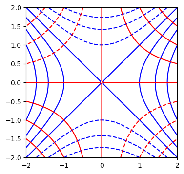

```python
fig, ax = plt.subplots(figsize=(4, 4))
x = np.linspace(-2, 2, 50)
X, Y = np.meshgrid(x, x); Z = X + 1j*Y
F = Z*Z

ax.contour (X,Y,F.real,colors='b')
ax.contour (X,Y,F.imag,colors='r')
plt.show()
```

### Laplace Equation

If the Cauchy-Riemann conditions are satisfied, then $u$ and $v$ are **harmonic functions**, i.e. they are solutions of the **Laplace equation**:

$$ u_{xx} + u_{yy} = 0 $$

$$ v_{xx} + v_{yy} = 0 $$

or, explicitly written:

$$ (\frac{\partial ^2}{\partial x^2} + \frac{\partial ^2}{\partial y^2}) u = 0 $$$$ (\frac{\partial ^2}{\partial x^2} + \frac{\partial ^2}{\partial y^2}) v = 0 $$

or, shorter:

$$ \Delta u = 0 $$

$$ \Delta v = 0 $$

which can be proved by derivation of the Cauchy-Riemann equations. It is named after Pierre-Simon Laplace (1749-1827), who made use of it being concerned with planetary motions. There are several areas of applications in natural sciences and engineering, where variables are required to fulfill the Laplace equation.

#### Potential

Most applications of the Laplace equation result from settings where a so-called **potential** is involved. The potential is a scalar function $\phi$, whose gradient is a vector field **v**: $$ \mathbf{v} = -\nabla \phi = -(\partial_x,\partial_y)^T \phi $$

If the vector field obeys the continuity equation $\nabla \cdot \mathbf{v} = 0$, the Laplace equation results:

$$\nabla \cdot \nabla \phi = -\nabla \cdot \mathbf{v} = 0 $$

The Laplace equation can be written as $ \phi_{xx} + \phi_{yy} = 0 $ in 2 dimensions, and as $ \phi_{xx} + \phi_{yy} + \phi_{zz} = 0 $ in 3 dimensions. It is a special case of the **Poisson equation** that allows a non-zero right hand side.

Application examples: The gravitational field can be derived from the gravitational potential (potential energy per unit mass), **Ohm's Law** determines the electric field due to the electrostatic potential, **Fourier's Law** relates heat fluxes to the temperature gradients, **Fick's Law** describes the diffusive fluxes of a chemical as gradients of the concentration (chemical potential), **Darcy's Law** deals with porous media flow resulting from hydraulic head gradients. In fluid dynamics the $\nabla \cdot \mathbf{v} = 0$ is valid for incompressible fluids, i.e. fluids with constant density. A fluid can also be termed incompressible, if the flow velocities are much smaller than those of the pressure waves. This can be fulfilled in aeradynamics, where potential flow has important applications.

For instance, in electrostatics one may have a *boundary-value problem* usually asking for the electrostatic potential between conductors, on which the potential is known. In such cases, the surface of each conductor is considered as a boundary, and by knowing the value of the potential on each boundary, the solution of the Laplace equation determines the potential between the conductors.

The Laplace equation consists of two important properties. The first property states that the solution of the Laplace equation is unique (*uniqueness theorem*). The second property states that the solutions of the Laplace equation formula hold good with the *superposition principle*.

#### Superposition Principle

The superposition principle arises directly from the fact that the Laplace's equation is linear in the potential. Thus, if $\phi$ is a solution of the Laplace equation, then also $a\phi$ is a solution for real numbers $a$. If $\phi_1$ is a and $\phi_2$ are solutions, also $\phi_1 + \phi_2$ is a solution.

We say potentials can be superposed. If $\phi_1$, $\phi_2$, $\phi_3 \cdots$, are solutions of the Laplace equation then for real numbers $a_1, a_2, a_3 \cdots$

$$ \nabla \cdot \nabla (a_1 \phi_1 + a_2 \phi_2 + a_3 \phi_3 + \cdots) = 0$$

The superposition principle is essential for the derivation of solutions of the Laplace equation.

Dealing with complex analysis the formulations can be modified for complex numbers and complex valued functions. Dealing with complex valued functions, we speak of a **complex potential** $\Phi$, if both its real and imaginary parts fulfill the Laplace equation. According to the superposition principle complex potentials can be added and multiplied by complex numbers and the result still fulfills the Laplace equation.

The following example shows how the flow field resulting from one source and one sink can be constructed by superposition the terms (here: logarithms) for the source and for the sink. The colours of the filled contours illustrate the potential. The white contour lines illustrate the imaginary part. In the following chapter the latter will be referred to as streamfunction.

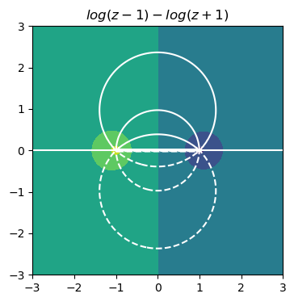

```python
fig, ax = plt.subplots(figsize=(4, 4))

x = np.linspace(-3, 3, 100)
X, Y = np.meshgrid(x, x)
Z = X + 1j*Y
F = np.log(Z-1)-np.log(Z+1)

ax.set_title('$log(z-1)-log(z+1)$')
plt.contourf(X, Y, np.real(F))
plt.contour(X, Y, np.imag(F),colors='white');
plt.show()
```

### Rotation

In fluid dynamics, the rotation (or **vorticity** $\vec{\omega }$) is defined by the cross-product $\nabla \times \mathbf{v}$. For potential flow, i.e. when $\phi$ fulfills the Laplace equation it's rotation is zero:

$$ \vec{\omega }=\nabla \times \nabla \phi = 0 $$

which follows from te definition of the cross-product. For the velocity potential $\phi$ this is valid in 2D and 3D. For 2D the proof reads like this:

$$ \partial_x (\partial_y \phi) - \partial_y (\partial_x \phi) = (\partial_{xy}-\partial_{xy}) \phi =0 $$

We say such flow is **irrotational**, because the local rotation vanishes everywhere.

### Examples

Let's check the derivative of the logarithm $f(z)=1/z$.

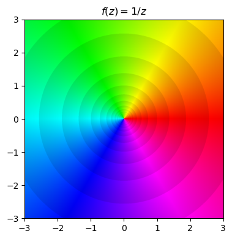

```python
fig, ax = plt.subplots(figsize=(4, 4))
x = np.linspace(-3, 3, 1000); y = x
X,Y = np.meshgrid(x, y); Z = X + 1j*Y

phaseplot(ax, 1/Z)
ax.set_title(r'$f(z) = 1/z$')
plt.tight_layout()
plt.show()
```

The coloring of the figure shows that at $z$=0 the function approaches different values depending on the angle. Thus the logarithm is not differentiable at $z$=0.

**Task 7**: Show the colorwheel plot of $f(z)=z^{-1/2}$. Is the function holomorphic in entire $\mathbb{C}$ ?

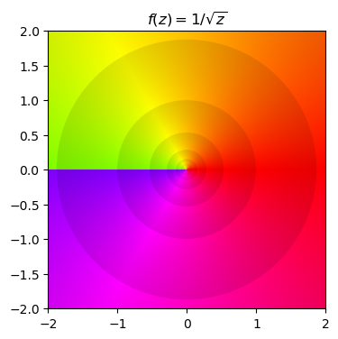

```python
fig, ax = plt.subplots(figsize=(4, 4))
x = np.linspace(-2, 2, 1000); y = x
X, Y = np.meshgrid(x, y); Z = X + 1j*Y
phaseplot (ax, Z**(-1/2))
ax.set_title('$f(z) = 1/\sqrt{z}$')
plt.show()
```

As the colorwheel is implemented here, green represents value of $2\pi /3$, magenta $10\pi /6$.